# Stats 531 Final project: POMP modeling to investigate Foreign Currency Exchange Rate volatility

# 6 Likelihood Slice

To get a brief view of when the log likelihood is maximized for each parameter, I am using likelihood slicing.

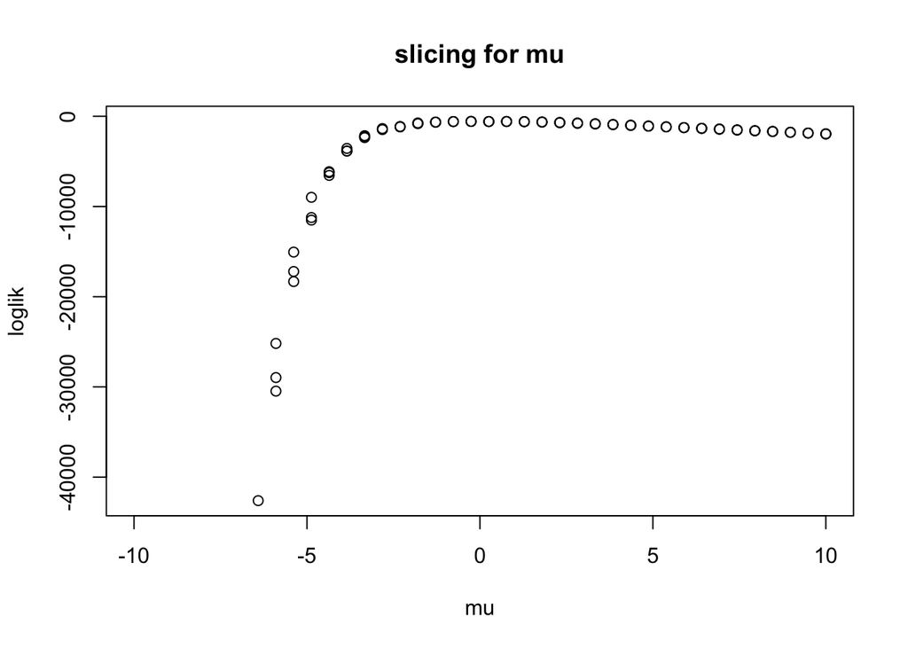

Figure 3. Slicing for mu

- The slicing for $\mu$ shows that the maximum of log likelihood is located when $\mu$ is aorund 0.

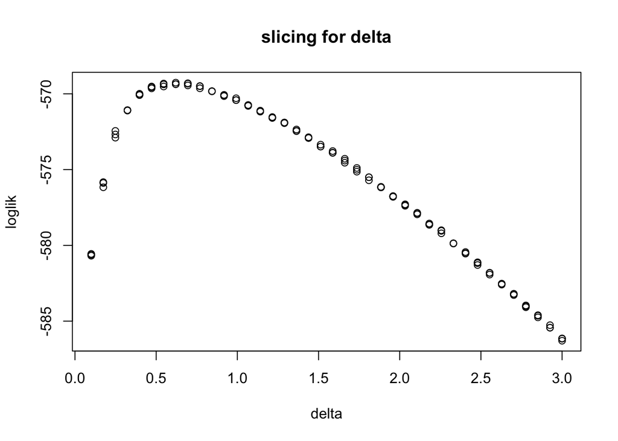

Figure 4. Slicing for delta

- The slicing for $\delta$ shows that the maximum of log likelihood is located when $\delta$ is around 0.6.

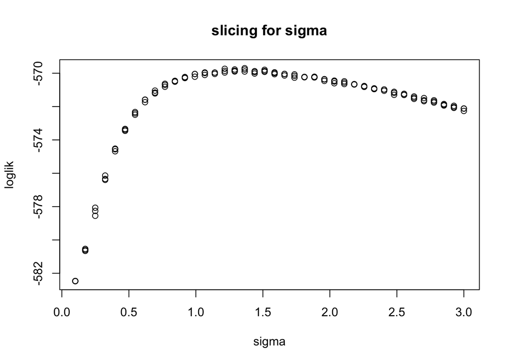

Figure 5. Slicing for sigma

- The slicing for $\sigma$ shows that the maximum of log likelihood is located when $\sigma$ is 1.3.

# 7 Partical Filter

```
##                          se
## -576.33375348    0.02237692
```

- The particle filter gives us an unbiased Monte Carlo estimate of the log likelihood. By using Number of particles of 2000, we got an estimate of -576.33 with a Monte standard error of 0.02.

# 8 Iterated Filtering on Data

## 8.1 Maximization and Likelihood Evaluation

```
##    Min. 1st Qu.  Median    Mean 3rd Qu.    Max.
##  -570.1  -569.9  -569.8  -569.8  -569.7  -569.5
```

The Local Maximum Search gives us a maximum of likelihood of -569.5 with a standard error of 0.007.

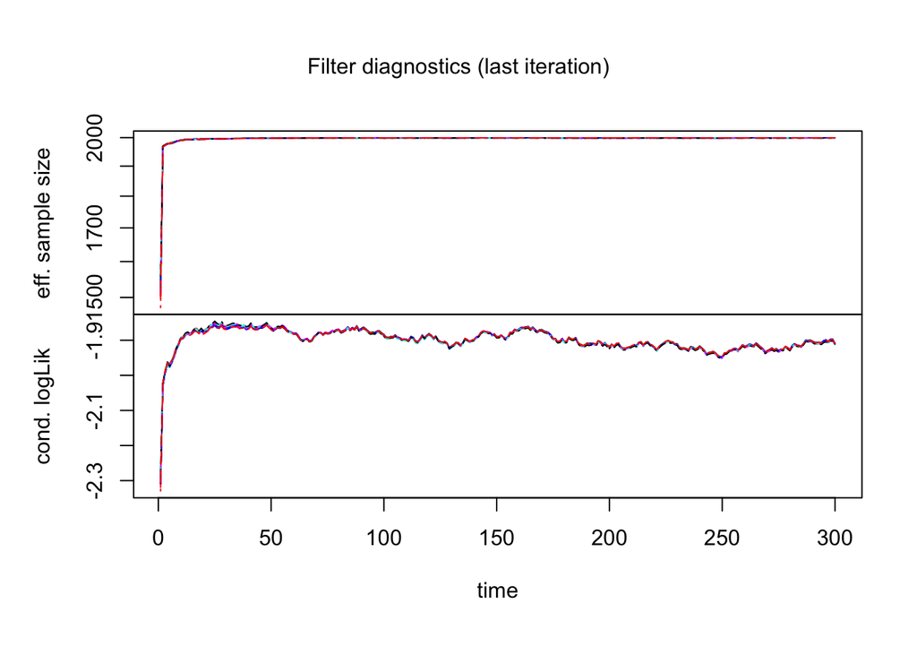

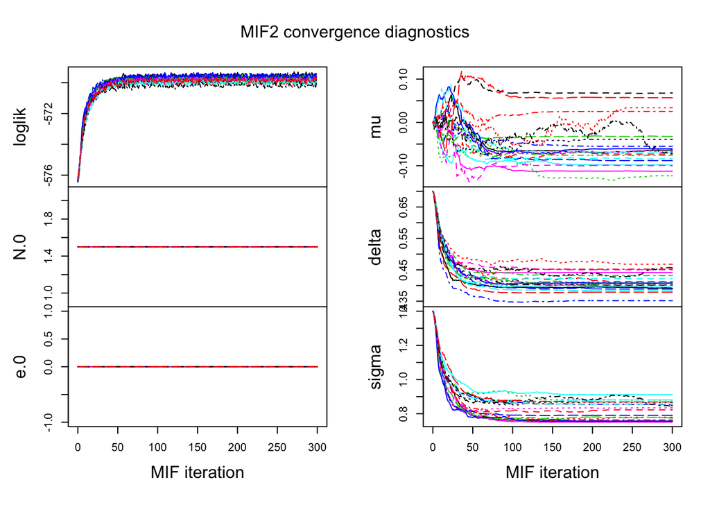

We can see that random walks are assigned to all 3 paramters mu, sigma and delta. Also the model is fitting the data well. The log-likelihood is increases initially and tends to separate to different values, indicating more iterations are required for a better result. All 3 parameters tends to separate values, while for each of the value we can observe a converging behavior.

## 8.2 Likelihood Surface Evaluation

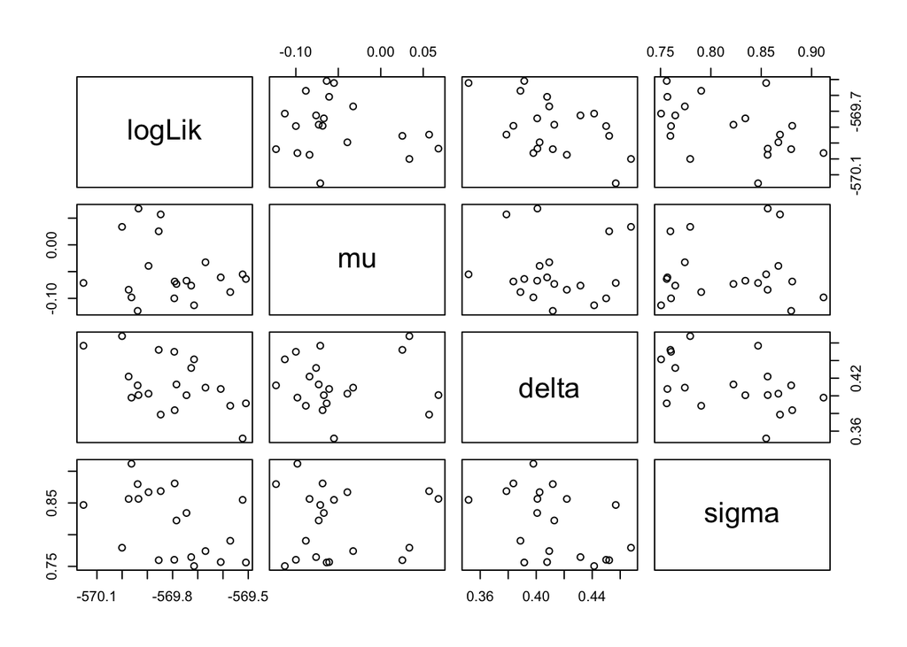

Figure 6. Pairwise Plot

The pairwise plot in Figure 6 shows us the geometry of the likelihood surface in a neighborhood (20 units around the maximum likelihood) for each parameter. I perform global search to see if the result is stable and compare the likelihood with the GARCH model.

# 9 Global Search with Randomized Starting Values

## 9.1 Iterated Filtering with randomized starting values

```
##    Min. 1st Qu.  Median    Mean 3rd Qu.    Max.
##  -569.1  -569.0  -569.0  -569.0  -569.0  -569.0
```

This serach took 120 minutes. Parameter estimation requires many and random starting values. Now I draw a starting value uniformly from an interval for each parameter. If the estimation gives stable result with different starting values, then it will provide confidence that an adequate global search has been carried out (Ionizes, E., 2016).It gives us a best likelihood of -569.0 with a standard error of 0.008. The likelihood is similar to our local search and the global search provides a quite stable statistic.

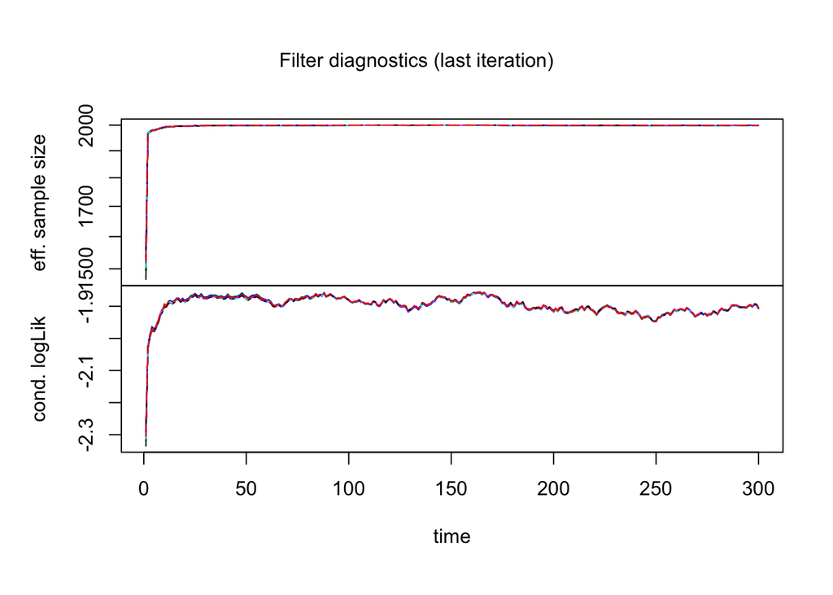

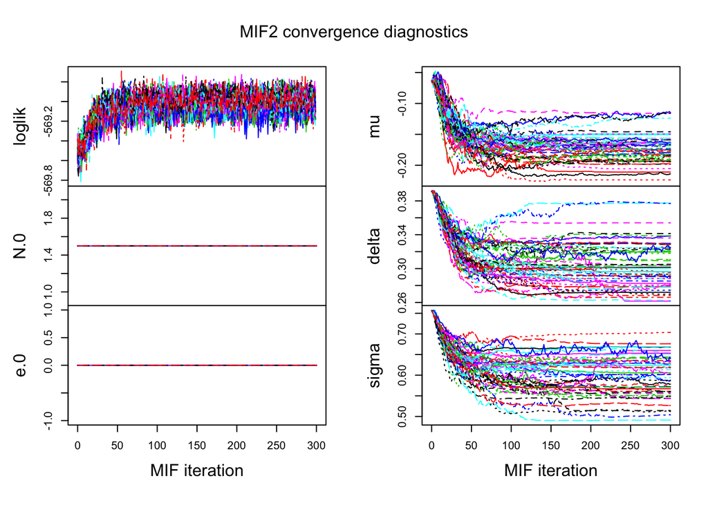

The log-likelihood is increases initially and tends to separate to different values, indicating more iterations are required for a better result.All 3 parameters i.e mu, sigma and delta tends to separate values, while for each of the value we can observe a converging behavior.

## 9.2 Global Geometry of the likelihood surface

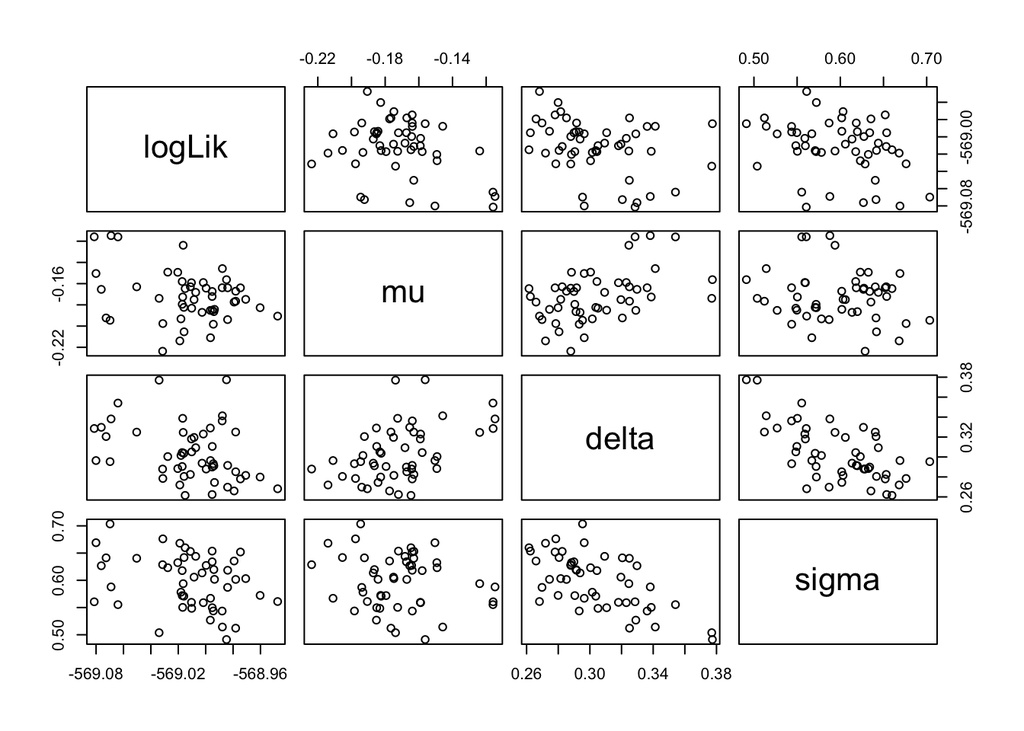

Figure 7. Pairwise Plot

The pairwise plot in Figure 7 shows, how does the geometry of the likelihood surface look like in the neighborhood (10 units around the maximum likelihood) for each parameter. We see optimization attempts from diverse remote starting points can approach on MLE, but do not exceed it. This gives us resonable confidence in our MLE. The points are clustered and end up with comparable likelihoods though the parameters are drawn from different starting values. It indicates that the model gives stable maximization of likelihood.

# 10 GARCH Model

## 10.1 Model Description

- According to notes from the class, the GARCH(p,q) model has the form
  $$Y_n = \epsilon_n \sqrt{V_n},$$
  where
  $$V_n = \alpha_0 + \sum_{j=1}^p \alpha_j Y_{n-j}^2 + \sum_{k=1}^q \beta_k V_{n-k}$$
  and $\epsilon_{1:N}$ is white noise (Ionides E., 2016).

GARCH is Generalized AutoRegressive Conditional Heteroskedasticity model where the variance error is believed to be serially autocorrelated. It assumes that the variance of error term follows autoregressive moving average process.From comparing the GARCH(1,0), GARCH(0,1) and GARCH(1,1) model by checking their log likelihoods, I choose to implement the GARCH(0,1) model as it gives the largest likelihood.

## 10.2 Log Likelihood

```
## 'log Lik.' -560.0184 (df=2)
```